# STAT 1291: Data Science

Lab 12: Many models II–Data-driven model selection by cross validation

In this lab, we use the data set `mtcars` to understand a data-driven regression model selection by cross validation. Can you predict `mpg` using other variables?

```r
head(mtcars)
```

```
##                    mpg cyl disp  hp drat    wt  qsec vs am gear carb
## Mazda RX4         21.0   6  160 110 3.90 2.620 16.46  0  1    4    4
## Mazda RX4 Wag     21.0   6  160 110 3.90 2.875 17.02  0  1    4    4
## Datsun 710        22.8   4  108  93 3.85 2.320 18.61  1  1    4    1
## Hornet 4 Drive    21.4   6  258 110 3.08 3.215 19.44  1  0    3    1
## Hornet Sportabout 18.7   8  360 175 3.15 3.440 17.02  0  0    3    2
## Valiant           18.1   6  225 105 2.76 3.460 20.22  1  0    3    1
```

With the whole data set, we would fit a multiple linear regression model via:

```r
mod <- lm(mpg ~ ., data = mtcars)
```

To predict, one may use `broom::augment()`. (`add_predictions()` is another option, but does not work well with cross-validation.)

```r
library(broom)
library(dplyr)
library(tidyr)
augment(mod, mtcars) %>% select(.rownames, mpg, .fitted) %>% head()
```

```
##           .rownames  mpg  .fitted
## 1         Mazda RX4 21.0 22.59951
## 2     Mazda RX4 Wag 21.0 22.11189
## 3        Datsun 710 22.8 26.25064
## 4    Hornet 4 Drive 21.4 21.23740
## 5 Hornet Sportabout 18.7 17.69343
## 6           Valiant 18.1 20.38304
```

#### Exercises

1. Compute the sum of squared errors from the fitted regression model. The formula is
   $$\mbox{SSE} = \sum_{i=1}^n (y_i - \hat{y}_i)^2.$$
2. With suitable assumptions on the population, which coefficients are significantly different from zero? [Hint: the answer is either all or nothing.]

This is an evidence of an overfitting. We need to choose a smaller model (with a smaller set of variables involved). This may be achieved by cross-validation.

## List-columns

Before we discuss cross-validation, we’ll explore the list-column data structure. An example of a list-column data set is shown below. See that the variable “x” has “list” values.

```r
temp_tbl <- tribble(
   ~x, ~y,
  1:3, "1, 2",
  3:5, "3, 4, 5"
)
temp_tbl
```

```
## # A tibble: 2 x 2
##           x       y
##      <list>   <chr>
## 1 <int [3]>    1, 2
## 2 <int [3]> 3, 4, 5
```

List-columns are implicit in the definition of the data frame: a data frame is a named list of equal length vectors. A list is a vector, so it’s always been legitimate to use a list as a column of a data frame.

A list-column data set consists of *nested* lists.

Why would you need to use a list-column? Here’s one example for multivalued summaries. One restriction of `dplyr::summarize()` is that it only works with summary functions that return a single value. That means that you can’t use it with functions like `quantile()` that return a vector of arbitrary length:

```r
quantile(mtcars$mpg)
```

```
##     0%    25%    50%    75%   100%
## 10.400 15.425 19.200 22.800 33.900
```

The following code does not work, because `summarize()` expects a single value.

```r
mtcars %>%
  group_by(cyl) %>%
  summarize(q = quantile(mpg))
```

You can however, wrap the result in a list! This obeys the contract of `summarize()`, because each summary is now a list (a vector) of length 1.

```r
mtcars %>%
  group_by(cyl) %>%
  summarise(q = list(quantile(mpg)))
```

```
## # A tibble: 3 x 2
##     cyl         q
##   <dbl>    <list>
## 1     4 <dbl [5]>
## 2     6 <dbl [5]>
## 3     8 <dbl [5]>
```

Use `tidyr::unnest()` to transform a list-column data set to a data frame. `unnest()` works by repeating the regular columns once for each element of the list-column. For example, in the following very simple example we repeat the first row 4 times (because there the first element of y has length four), and the second row once:

```r
tibble(x = 1:2, y = list(1:4, 1)) %>% unnest(y)
```

```
## # A tibble: 5 x 2
##       x     y
##   <int> <dbl>
## 1     1     1
## 2     1     2
## 3     1     3
## 4     1     4
## 5     2     1
```

To make useful results with `unnest()`, you’ll also need to capture the probabilities:

```r
probs <- c(0.01, 0.25, 0.5, 0.75, 0.99)
mtcars %>%
  group_by(cyl) %>%
  summarize(p = list(probs), q = list(quantile(mpg, probs))) %>%
  unnest()
```

```
## # A tibble: 15 x 3
##      cyl     p      q
##    <dbl> <dbl>  <dbl>
##  1     4  0.01 21.410
##  2     4  0.25 22.800
##  3     4  0.50 26.000
##  4     4  0.75 30.400
##  5     4  0.99 33.750
##  6     6  0.01 17.818
##  7     6  0.25 18.650
##  8     6  0.50 19.700
##  9     6  0.75 21.000
## 10     6  0.99 21.376
## 11     8  0.01 10.400
## 12     8  0.25 14.400
## 13     8  0.50 15.200
## 14     8  0.75 16.250
## 15     8  0.99 19.135
```

The intermediate results of cross-validation are stored as list-column data structures.

## What is cross-validation?

Cross-validation is based on two principles:

1. Never use the same data to fitting and assessment
2. Use your data as much as possible

In cross validation, we will set aside a small portion of data for assessment, using the majority of data for fitting. Just because your model performs well on the majority (this is known as in-sample testing), it does not imply that it will perform as well on the set-aside data (out-of-sample testing). The aim is to “train” a model that performs well on the set-aside “testing” data. To use the data as much as possible, we will randomly divide the data into $K$ equal-sized portions, repeat the training-testing for each of $K$ portions.

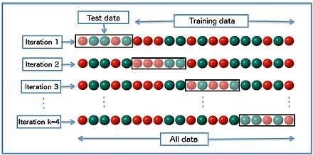

K-fold cross-validation with K = 4

Implemenation of $K$-fold cross validation amounts to dividing the rows of the data into $K$-portions. We will use packages `broom` and `modelr` in efficiently implementing cross-validation for variable selection in linear regression.

## Creating folds

Before worrying about models, we can generate K folds using `crossv_kfold()` from the `modelr` package. Let’s practice with the mtcars data to keep things simple.

```r
library(modelr)
set.seed(1)
folds <- crossv_kfold(mtcars, k = 5)
folds
```

```
## # A tibble: 5 x 3
##            train           test   .id
##           <list>         <list> <chr>
## 1 <S3: resample> <S3: resample>     1
## 2 <S3: resample> <S3: resample>     2
## 3 <S3: resample> <S3: resample>     3
## 4 <S3: resample> <S3: resample>     4
## 5 <S3: resample> <S3: resample>     5
```

The function `crossv_kfold()` takes a data frame and randomly partitions it’s rows (1 to 32 for `mtcars`) into k roughly equal groups. We’ve partitioned the row numbers into $k = 5$ groups. The results are returned as a tibble like the one above.

Each cell in the test column contains a `resample` object, which is an efficient way of referencing a subset of rows in a data frame. Think of each cell as a reference to the rows of the data frame belonging to each partition. For example, the following tells us that the first partition of the data references rows 5, 9, 17, 20, 27, 28, 29, which accounts for roughly 1 / k of the total data set (7 of the 32 rows).

```r
folds$test[[1]]
```

```
## <resample [7 x 11]> 5, 9, 17, 20, 27, 28, 29
```

#### Exercise

3. What are the row numbers in the first partition of the “training” data? Notice that the first train object references all rows except 5, 9, 17, 20, 27, 28, 29.

## Fitting models to training data

We can now run a model on the data referenced by each train object, and validate the model results on each corresponding partition in test. We use `purrr::map()` for this task.

```r
library(dplyr)
library(purrr)
folds <- folds %>% mutate(model = map(train, ~ lm(mpg ~ ., data = .)))
folds
```

```
## # A tibble: 5 x 4
##            train           test   .id    model
##           <list>         <list> <chr>   <list>
## 1 <S3: resample> <S3: resample>     1 <S3: lm>
## 2 <S3: resample> <S3: resample>     2 <S3: lm>
## 3 <S3: resample> <S3: resample>     3 <S3: lm>
## 4 <S3: resample> <S3: resample>     4 <S3: lm>
## 5 <S3: resample> <S3: resample>     5 <S3: lm>
```

Let’s see the new commands one by one:

- `folds %>% mutate(model = ...)` is adding a new model column to the `folds` tibble.
- `map(train, ...)` is applying a function (`lm()` in this case) to each of the cells in `train`. (See `?purrr::map`)
- `~ lm(...)` is the regression model applied to each `train` cell.
- `data = .` specifies that the data for the regression model will be the data referenced by each `train` object.

Note that `map(train, ~ lm(mpg ~ ., data = .))` is roughly the same as

```r
model_tmp <- list()
attach(folds) # used to call $train directly
for( i in 1:nrow(folds)) {
  model_tmp[[i]] <- lm(mpg ~ ., data = train[[i]])
}
detach(folds)
```

`folds %>% mutate(...)` is the same as adding a new variable `model_tmp` (whose values are given by the above `for` loop.) Compare the values of `model_tmp` and `folds$model`.

The result is a new model column containing fitted regression models based on each of the train data (i.e., the whole data set excluding each partition).

For example, the model fitted to our first set of training data is:

```r
folds$model[[1]] %>% summary()
```

```
##
## Call:
## lm(formula = mpg ~ ., data = .)
##
## Residuals:
##     Min      1Q  Median      3Q     Max
## -3.6540 -0.9116  0.0439  0.9520  4.2811
##
## Coefficients:
##               Estimate Std. Error t value Pr(>|t|)
## (Intercept) -44.243933  31.884363  -1.388   0.1869
## cyl           0.844966   1.064141   0.794   0.4404
## disp          0.016800   0.015984   1.051   0.3110
## hp            0.004685   0.022741   0.206   0.8398
## drat          3.950410   1.989177   1.986   0.0670 .
## wt           -4.487007   2.016341  -2.225   0.0430 *
## qsec          2.327131   1.243095   1.872   0.0822 .
## vs           -3.963492   3.217176  -1.232   0.2382
## am           -0.550804   2.333252  -0.236   0.8168
## gear          5.476604   2.648708   2.068   0.0577 .
## carb         -1.595979   1.104272  -1.445   0.1704
## ---
## Signif. codes:  0 '***' 0.001 '**' 0.01 '*' 0.05 '.' 0.1 ' ' 1
##
## Residual standard error: 2.159 on 14 degrees of freedom
## Multiple R-squared:  0.9092, Adjusted R-squared:  0.8444
## F-statistic: 14.02 on 10 and 14 DF,  p-value: 1.205e-05
```

## Predicting the test data

The next step is to use each model for predicting the outcome variable in the corresponding test data. We have seen that `augment()` can be used to obtain the predicted values. We will use `purrr::map2()` to iterate through each model and set of test data in parallel to compute the predicted values for the test data.

```r
folds %>% mutate(predicted = map2(model, test, ~ augment(.x, newdata = .y)))
```

```
## # A tibble: 5 x 5
##            train           test   .id    model             predicted
##           <list>         <list> <chr>   <list>                <list>
## 1 <S3: resample> <S3: resample>     1 <S3: lm> <data.frame [7 x 13]>
## 2 <S3: resample> <S3: resample>     2 <S3: lm> <data.frame [7 x 13]>
## 3 <S3: resample> <S3: resample>     3 <S3: lm> <data.frame [6 x 13]>
## 4 <S3: resample> <S3: resample>     4 <S3: lm> <data.frame [6 x 13]>
## 5 <S3: resample> <S3: resample>     5 <S3: lm> <data.frame [6 x 13]>
```

To extract the relevant information from these predicted results, we’ll `unnest` the data frames in the list `predicted`. `tidy::unnest()` makes each element of the list its own row.

```r
library(tidyr)
cv.pred <- folds %>% mutate(predicted = map2(model, test, ~ augment(.x, newdata = .y))) %>% unnest(predicted)
head(cv.pred)
```

```
## # A tibble: 6 x 14
##     .id   mpg   cyl  disp    hp  drat    wt  qsec    vs    am  gear  carb
##   <chr> <dbl> <dbl> <dbl> <dbl> <dbl> <dbl> <dbl> <dbl> <dbl> <dbl> <dbl>
## 1     1  18.7     8 360.0   175  3.15 3.440 17.02     0     0     3     2
## 2     1  22.8     4 140.8    95  3.92 3.150 22.90     1     0     4     2
## 3     1  14.7     8 440.0   230  3.23 5.345 17.42     0     0     3     4
## 4     1  33.9     4  71.1    65  4.22 1.835 19.90     1     1     4     1
## 5     1  26.0     4 120.3    91  4.43 2.140 16.70     0     1     5     2
## 6     1  30.4     4  95.1   113  3.77 1.513 16.90     1     1     5     2
## # ... with 2 more variables: .fitted <dbl>, .se.fit <dbl>
```

- `.id` refers to the fold id. In the first fold, the datum corresponding to the value `mpg = 18.7` was a part of testing data; the first value of `.fitted` was from a model trained on the training data. We can now compute the cross-validated sum of squared errors:

$$\mbox{SSE} = \sum_{i=1}^n (y_i - \hat{y}_i)^2,$$
where in this case, $\hat{y}_i$ and $y_i$ are independent.

```r
cv.pred %>% summarize(SSE =  sum(mpg - .fitted)^2)
```

```
## # A tibble: 1 x 1
##        SSE
##      <dbl>
## 1 593.4018
```

#### Exercise

4. Confirm that the SSE from cross validation is much larger than the SSE from Exercise 1.

## Repeat for many models

`mtcars` has 10 explanatory variables; there are $2^10 = 1024$ possible models. Experimenting with all models is extremely time-consuming. We will simply choose a few models to compare. For this, we create all model formulas with 3 predictors.

```r
# No need to understand what is going on in this R chunk
vars <- colnames(select(mtcars,-mpg))
allsubmodels <- combn(vars,3)
Formulas <- apply(allsubmodels,2, function(x) paste("mpg ~",paste(x,collapse="+")))
head(Formulas)
```

```
## [1] "mpg ~ cyl+disp+hp"   "mpg ~ cyl+disp+drat" "mpg ~ cyl+disp+wt"
## [4] "mpg ~ cyl+disp+qsec" "mpg ~ cyl+disp+vs"   "mpg ~ cyl+disp+am"
```

Among the 120 models, which one will provide the smallest cross-validated SSE? See if you understand the following commands.

```r
set.seed(1)
folds <- crossv_kfold(mtcars, k = 5) # start over

Model_validation <- list()

for(i in seq_along(Formulas)){
  SSE <- folds %>%
    mutate(model = map(train, ~ lm(as.formula(Formulas[i]), data = .))) %>%
    unnest(predicted = map2(model, test, ~ augment(.x, newdata = .y))) %>%
    summarize(SSE =  sum(mpg - .fitted)^2)
  Model_validation[[i]] <- tibble(formula = Formulas[i], SSE = as_vector(SSE))
}

bind_rows(Model_validation) %>% arrange(SSE) %>% head()
```

```
## # A tibble: 6 x 2
##              formula          SSE
##                <chr>        <dbl>
## 1   mpg ~ drat+vs+am 0.0005707902
## 2   mpg ~ hp+drat+wt 0.0010271059
## 3   mpg ~ hp+wt+carb 0.0043227292
## 4   mpg ~ hp+vs+gear 0.0050046498
## 5    mpg ~ cyl+wt+vs 0.0064563203
## 6 mpg ~ hp+drat+qsec 0.0086264585
```